# Detection of Chagas Disease from the ECG: PhysioNet Challenge 2025

# SHAP Values

We can use the SHAP values to explain the predictions of the XGBoost model, as it has very good results.

SHAP values are a good way to explain the predictions of the model. They are a good alternative to the permutation importance and they are more accurate. Their origin comes from the Shapley values in game theory, which are used to explain the contribution of each player to the game. Mathematically, SHAP values assign an importance value to each feature by considering all possible combinations of features and computing the marginal contribution of a feature across these combinations.

First of all, we define the explainer with a sample of the train set composed by 100 points. Then we compute the SHAP values for the test set. Larger sample sizes would be better, but it would also increase the computational time (which already is quite high around 1h for the XGBoost model).

```python
f = lambda x: xbm.predict_proba(x)[:,1]
explainer = shap.KernelExplainer(f, shap.sample(X_train, 100), link='logit', seed=SEED)
```

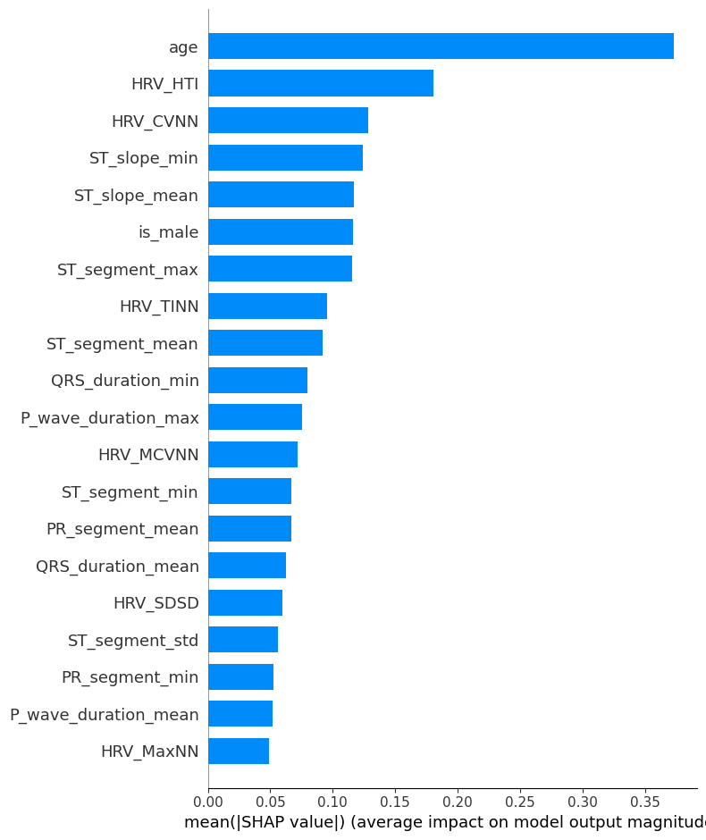

```python
shap.summary_plot(shap_values, X_test, plot_type='bar', max_display=20)
```

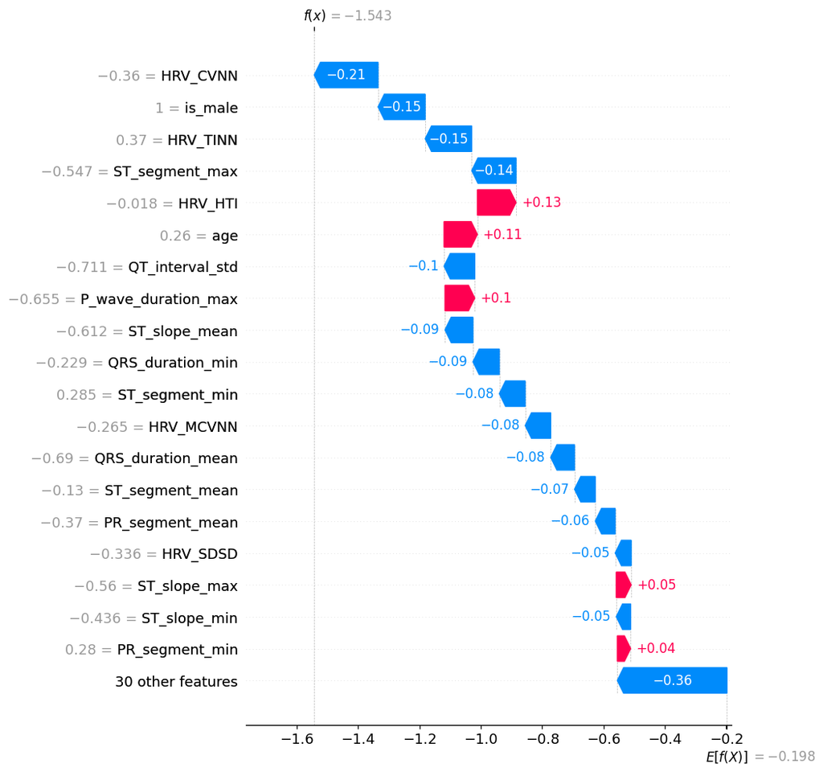

```python
shap.waterfall_plot(shap.Explanation(values=shap_values[0], base_values=explainer.expected_value, data=X_test.iloc[0], feature_names=X.columns.tolist()), max_display=20)
```

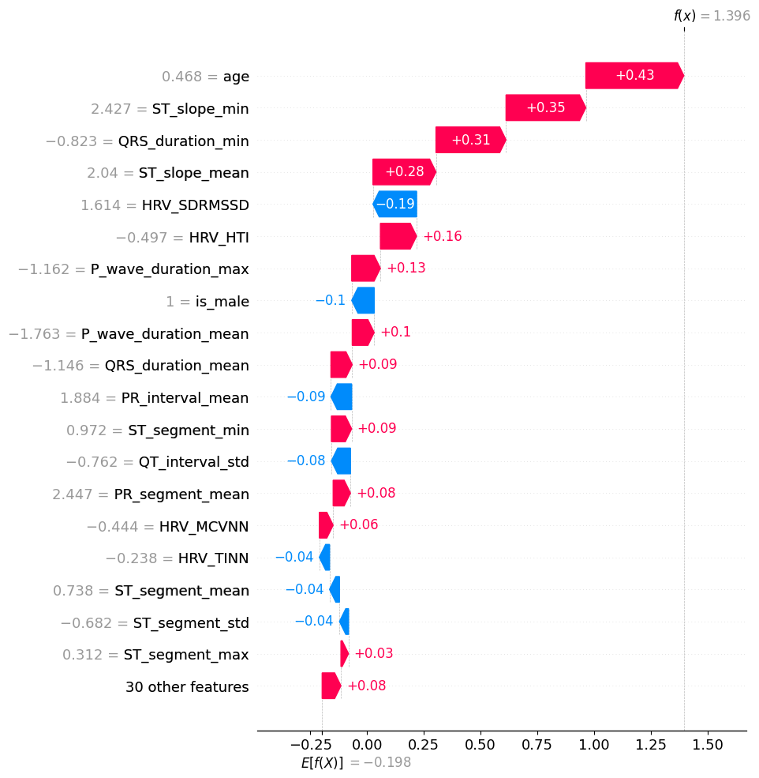

```python
shap.waterfall_plot(shap.Explanation(values=shap_values[1], base_values=explainer.expected_value, data=X_test.iloc[1], feature_names=X.columns.tolist()), max_display=20)
```

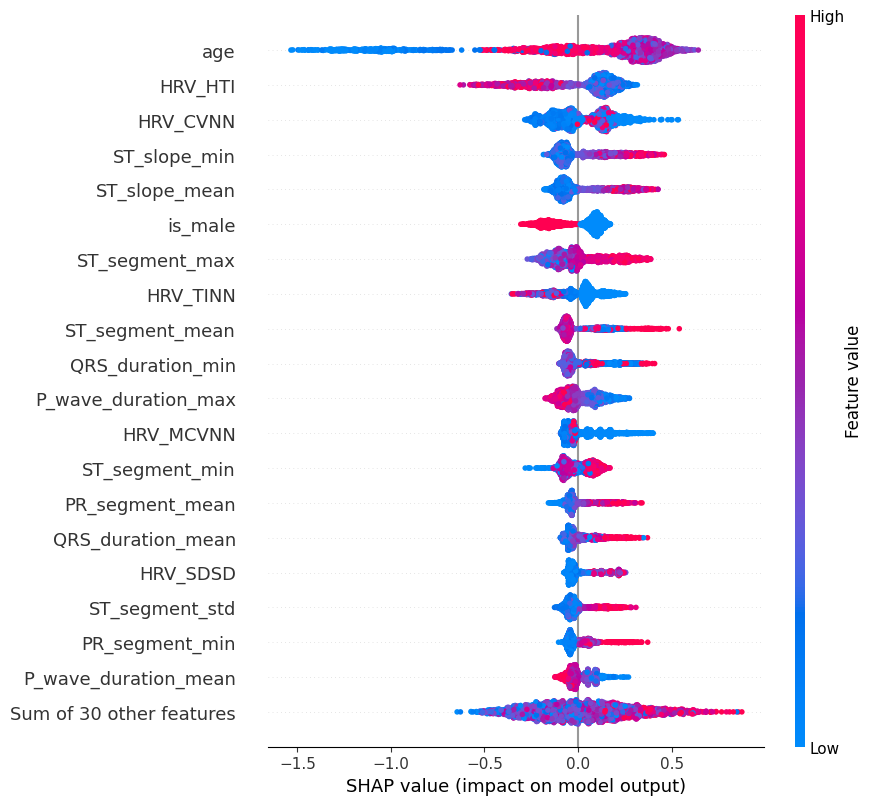

```python
shap.plots.beeswarm(shap_values, max_display=20)
```

# Feature selection

```python
shap_mean = np.abs(shap_values.values).mean(axis=0)
shap_mean = pd.Series(index=X.columns, data=shap_mean)
shap_mean.sort_values(ascending=False, inplace=True)
best_20_shap = shap_mean.head(20)
```

```python
X_train_fs = X_train[best_20_shap.index]
X_test_fs = X_test[best_20_shap.index]

base_est = xgboost.XGBClassifier(tree_method='hist', importance_type='total_gain')
param_grid={'max_depth': [2, 3, 4], 'n_estimators': list(range(20, 41, 5)), 'reg_lambda': np.linspace(0, 500, 6)}
gscv_fs = GridSearchCV(base_est, param_grid=param_grid, n_jobs=-1)
gscv_fs.fit(X_train_fs, y_train)
xbm_fs, xbm_params_fs = gscv_fs.best_estimator_, gscv_fs.best_params_
y_pred = xbm_fs.predict_proba(X_test_fs)[:, 1]
xbm_score_test_fs = roc_auc_score(y_test, y_pred)

print(f'AUC score for max_depth={xbm_params_fs["max_depth"]}, n_estimators={xbm_params_fs["n_estimators"]}, reg_lambda={xbm_params_fs["reg_lambda"]:.2f}: {xbm_score_test_fs:.4f} (test)')
```

```
AUC score for max_depth=4, n_estimators=40, reg_lambda=100.00: 0.7804 (test)
```

```
Accuracy: 0.7023
ROC-AUC: 0.7804
F1-score: 0.7103
F-beta score 0.6992238980817104
```

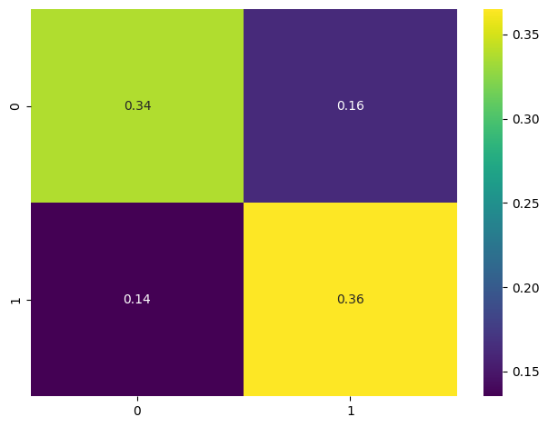

```python
results_dict['XGBoost-SHAP'] = print_results(xbm_fs, y_test, xbm_fs.predict(X_test_fs), xbm_fs.predict_proba(X_test_fs)[:, 1])
```

```python
bfs = BorutaPy(xbm, n_estimators='auto', max_iter=100, verbose=0, random_state=SEED, early_stopping=True)
bfs.fit(X=X, y=y)
```

```
BorutaPy(early_stopping=True,
         estimator=XGBClassifier(base_score=None, booster=None, callbacks=None,
                                 colsample_bylevel=None, colsample_bynode=None,
                                 colsample_bytree=None, device=None,
                                 early_stopping_rounds=None,
                                 enable_categorical=False, eval_metric=None,
                                 feature_types=None, gamma=None,
                                 grow_policy=None, importance_type='total_gain',
                                 interaction_constraints=None,
                                 learning_rate=None, max_bin=None,
                                 max_cat_threshold=None, max_cat_to_onehot=None,
                                 max_delta_step=None, max_depth=4,
                                 max_leaves=None, min_child_weight=None,
                                 missing=nan, monotone_constraints=None,
                                 multi_strategy=None, n_estimators=173,
                                 n_jobs=None, num_parallel_tree=None,
                                 random_state=381215112, ...),
         n_estimators='auto',
         random_state=RandomState(MT19937) at 0x7CB9D13DA540)
```

```python
pd.DataFrame(data=bfs.ranking_, index=X.columns).rename(columns={0: 'Ranking'}).sort_values(by='Ranking', ascending=True)
```

|  | Ranking |
| --- | --- |
| P_wave_duration_mean | 1 |
| ST_segment_mean | 1 |
| ST_segment_std | 1 |
| ST_segment_min | 1 |
| ST_segment_max | 1 |
| age | 1 |
| ST_slope_min | 1 |
| HRV_MeanNN | 1 |
| HRV_SDSD | 1 |
| HRV_CVNN | 1 |
| HRV_CVSD | 1 |
| HRV_MCVNN | 1 |
| HRV_SDRMSSD | 1 |
| HRV_Prc20NN | 1 |
| HRV_HTI | 1 |
| HRV_TINN | 1 |
| QT_interval_max | 1 |
| QT_interval_min | 1 |
| ST_slope_mean | 1 |
| QRS_duration_min | 1 |
| QRS_duration_mean | 1 |
| PR_segment_mean | 1 |
| QT_interval_mean | 2 |
| ST_slope_max | 2 |
| P_wave_duration_max | 3 |
| P_wave_duration_std | 4 |
| HRV_Prc80NN | 6 |
| HRV_MedianNN | 6 |
| is_male | 6 |
| PR_segment_std | 8 |
| ST_slope_std | 9 |
| HRV_pNN20 | 9 |
| PR_segment_min | 11 |
| QT_interval_std | 12 |
| HRV_MaxNN | 13 |
| PR_interval_min | 14 |
| HRV_MinNN | 15 |
| QRS_duration_std | 16 |
| HRV_IQRNN | 16 |
| PR_interval_mean | 18 |
| PR_segment_max | 18 |
| P_wave_duration_min | 20 |
| QRS_duration_max | 21 |
| PR_interval_max | 22 |
| PR_interval_std | 23 |
| HRV_SDNN | 24 |
| HRV_pNN50 | 25 |
| HRV_RMSSD | 26 |
| HRV_MadNN | 27 |

```python
X_train_boruta = X_train[X.columns[bfs.ranking_ == 1].values]
X_test_boruta = X_test[X.columns[bfs.ranking_ == 1].values]

base_est = xgboost.XGBClassifier(tree_method='hist', importance_type='total_gain')
param_grid={'max_depth': [2, 3, 4], 'n_estimators': list(range(20, 41, 5)), 'reg_lambda': np.linspace(0, 500, 6)}
gscv_boruta = GridSearchCV(base_est, param_grid=param_grid, n_jobs=-1)
gscv_boruta.fit(X_train_boruta, y_train)
xbm_boruta, xbm_params_boruta = gscv_boruta.best_estimator_, gscv_boruta.best_params_
y_pred = xbm_boruta.predict_proba(X_test_boruta)[:, 1]
xbm_score_test_boruta = roc_auc_score(y_test, y_pred)

print(f'AUC score for max_depth={xbm_params_boruta["max_depth"]}, n_estimators={xbm_params_boruta["n_estimators"]}, reg_lambda={xbm_params_boruta["reg_lambda"]:.2f}: {xbm_score_test_boruta:.4f} (test)')
```

```
AUC score for max_depth=4, n_estimators=35, reg_lambda=100.00: 0.7800 (test)
```

```
Accuracy: 0.7081
ROC-AUC: 0.7800
F1-score: 0.7160
F-beta score 0.70466852041563
```

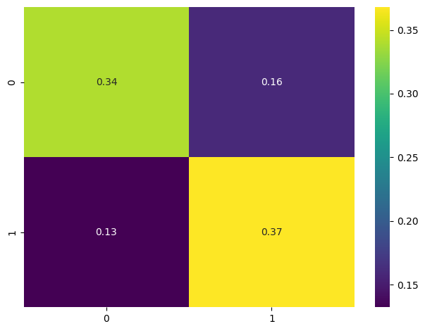

```python
results_dict['XGBoost-Boruta'] = print_results(xbm_boruta, y_test, xbm_boruta.predict(X_test_boruta), xbm_boruta.predict_proba(X_test_boruta)[:, 1])
```

```python
shap_20_feature_set = set(best_20_shap.index)
boruta_feature_set = set(X.columns[bfs.ranking_ == 1].values)
intersection = shap_20_feature_set.intersection(boruta_feature_set)

X_train_intersection = X_train[list(intersection)]
X_test_intersection = X_test[list(intersection)]

base_est = xgboost.XGBClassifier(tree_method='hist', importance_type='total_gain')
param_grid={'max_depth': [2, 3, 4], 'n_estimators': list(range(20, 41, 5)), 'reg_lambda': np.linspace(0, 500, 6)}
gscv_intersection = GridSearchCV(base_est, param_grid=param_grid, n_jobs=-1)
gscv_intersection.fit(X_train_intersection, y_train)
xbm_intersection, xbm_params_intersection = gscv_intersection.best_estimator_, gscv_intersection.best_params_
y_pred = xbm_intersection.predict_proba(X_test_intersection)[:, 1]
xbm_score_test_intersection = roc_auc_score(y_test, y_pred)

print(f'AUC score for max_depth={xbm_params_intersection["max_depth"]}, n_estimators={xbm_params_intersection["n_estimators"]}, reg_lambda={xbm_params_intersection["reg_lambda"]:.2f}: {xbm_score_test_intersection:.4f} (test)')
```

```
AUC score for max_depth=3, n_estimators=40, reg_lambda=100.00: 0.7741 (test)
```

```
Accuracy: 0.6943
ROC-AUC: 0.7741
F1-score: 0.7024
F-beta score 0.6915750915750916
```

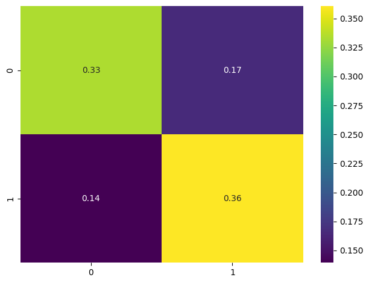

```python
results_dict['XGBoost-Intersection'] = print_results(xbm_intersection, y_test, xbm_intersection.predict(X_test_intersection), xbm_intersection.predict_proba(X_test_intersection)[:, 1])
```

```python
compare_models(xbm_fs.predict(X_test_fs), 'XGBoost-SHAP', xbm_boruta.predict(X_test_boruta), 'XGBoost-Boruta', y_test)
```

[output not shown]

```python
pd.DataFrame(results_dict)
```

|  | Logistic Regression | XGBoost | SVC | KNN | XGBoost-SHAP | XGBoost-Boruta | XGBoost-Intersection |
| --- | --- | --- | --- | --- | --- | --- | --- |
| acc | 0.681697 | 0.705006 | 0.706152 | 0.678258 | 0.702331 | 0.708063 | 0.694306 |
| auc | 0.745726 | 0.781293 | 0.766039 | 0.740854 | 0.780380 | 0.780037 | 0.774087 |
| f1 | 0.671141 | 0.714497 | 0.702284 | 0.654635 | 0.710301 | 0.715985 | 0.702381 |
| f_beta | 0.684932 | 0.701118 | 0.708041 | 0.684979 | 0.699224 | 0.704669 | 0.691575 |

# Deep Learning

## Why?

Another approach that we can try is to use **Deep Learning** with the aim of improving the results in terms of ROC AUC.

In this context, we can use any kind of deep learning model, such as a simple **feedforward neural network**, a **convolutional neural network**, or a **recurrent neural network**.

However, Fully Connected Neural Networks are not suitable for time series data, as they do not take into account the **temporal dependencies** in the data. Moreover, we do not have only one-dimensional data, but **12 leads** of ECG signals for each record and **demographic information**.

Thus, we can use a Convolutional Neural Network (CNN) to take into account the **spatial dependencies** in the data, as the ECG signals are two-dimensional data. In particular, we can use a **1D CNN** for each lead of the ECG signals and a Fully Connected Neural Network for the demographic information.

We can also use a Recurrent Neural Network (RNN) to take into account the temporal dependencies in the data, as the ECG signals are time series data. This RNN could be put on top of the CNN to take into account both the spatial and temporal dependencies in the data. This approach is the SOTA for a variety of tasks like **Sleep Stage Classification**, **ECG Classification**, etc.

Although these models are more complex than the previous ones, they can provide better results in terms of ROC AUC.

## Explainability?

Deep Learning models are often considered as black boxes, as they are very complex and it is difficult to understand how they make predictions. However, there are some techniques that can help us understand how the model makes predictions, such as SHAP values, LIME, and Grad-CAM. In particular, SHAP values can help us understand the importance of each feature in the model's predictions.

We will try to leverage the Deep Explainer of the SHAP library to explain the predictions of the Deep Learning model.

More sophisticated techniques like LIME and Grad-CAM can also be used to explain the predictions of the Deep Learning model. Grad-CAM can help us understand which parts of the ECG signals are important for the model's predictions as to highlight which leads are more important in the model's predictions. We hypothesize that the lead II is the most important one, as it is the most commonly used lead in ECG analysis but we will see if this is true by using Grad-CAM.

```python
class ECGDataset(Dataset):
    def __init__(self, features, labels):
        signals, ages, sexes, handcrafted = zip(*features)
        ages = np.array(ages)
        self.features = signals
        self.ages = (ages - ages.min()) / (ages.max() - ages.min())
        self.sexes = sexes
        self.labels = labels
        self.handcrafted = handcrafted
        self.min_len = min(signal.shape[0] for signal in signals)

    def __len__(self):
        return len(self.labels)

    def __getitem__(self, idx):
        signals = torch.tensor(self.features[idx], dtype=torch.float32)
        ages = torch.tensor(self.ages[idx], dtype=torch.float32)
        sexes = torch.tensor(self.sexes[idx], dtype=torch.float32)
        label = torch.tensor(self.labels[idx], dtype=torch.float)
        handcrafted = torch.tensor(self.handcrafted[idx], dtype=torch.float32)

        # Standardize the signals
        signals = (signals - signals.mean()) / signals.std()

        # Truncate the signals to half the maximum length
        signals = signals[:self.min_len :]

        signals = signals.transpose(0, 1)
        label = label.unsqueeze(0)

        #handcrafted = (handcrafted - handcrafted.min()) / (handcrafted.max() - handcrafted.min() + 1e-8)

        return signals, label, ages, sexes, handcrafted.squeeze(0)
```

```python
X_train, X_test, y_train, y_test = train_test_split(X, y, test_size=0.2, random_state=SEED, stratify=y)

X_train, X_val, y_train, y_val = train_test_split(X_train, y_train, test_size=0.10, random_state=SEED, stratify=y_train)

print("Train", len(X_train))
print("Val", len(X_val))
print("Test", len(X_test))
```

```
Train 9425
Val 1048
Test 2619
```

```python
BATCH_SIZE = 32

train_dataset = ECGDataset(X_train, y_train)
val_dataset = ECGDataset(X_val, y_val)
test_dataset = ECGDataset(X_test, y_test)
train_dloader = DataLoader(train_dataset, batch_size=BATCH_SIZE, shuffle=True, pin_memory=True)
val_dloader = DataLoader(val_dataset, batch_size=BATCH_SIZE, shuffle=False, pin_memory=True)
test_dloader = DataLoader(test_dataset, batch_size=BATCH_SIZE, shuffle=False)
```

## Model

The model we are going to use is a 1D Conv SE-ResNet18, which is a convolutional neural network with squeeze-and-excitation blocks and a ResNet18 architecture. The ResNet18 architecture is a convolutional neural network with residual connections that is widely used for image classification tasks. The squeeze-and-excitation blocks are used to model the dependencies between the channels of the input data, which can be useful for ECG signals, as they have multiple leads that are related to each other. In this way, the model can learn the spatial dependencies in the data and improve the performance of the model by focusing on the most important leads.

In order to integrate the demographic information into the model, we can use a Fully Connected Neural Network that takes the demographic information as input and outputs a vector of the same size as the output of the convolutional neural network. This vector can be concatenated with the output of the convolutional neural network and passed through a linear layer to get the final output of the model.

More sophisticated techniques can be used to integrate the demographic information into the model, such as attention mechanisms, by weighting the output of the convolutional neural network based on the demographic information. Alternatives might esplore the Feature-wise Linear Modulation (FiLM) layers by conditioning the convolutional neural network on the demographic information. This intuition comes from the fact that the demographic information can be used to modulate the features extracted by the convolutional neural network, so that the model can learn that specific patterns might also be related to the demographic information. This is particularly useful when the demographic information is related to the target variable, as it can help the model to learn the relationship between the demographic information and the target variable. As we have seen in the EDA, the demographic information is related to the target variable, so it can be useful to integrate it into the model by using a concatenation or a modulation approach.

> **Note**: For our purpose the concatenation approach is enough, but the other approaches can be explored in future work to improve the performance of the model on a greater scale of training data.

```python
resnet_params = {
    'layers': [2, 2, 2, 2],
    "in_channel":12,
    "out_channel":1,
    "zero_init_residual":False
}
```

```python
device = torch.device("cuda" if torch.cuda.is_available() else "cpu")

# Initialize model
model = ResNet(BasicBlock, **resnet_params)
model.to(device)

# Positive class weight
pos_weight = (y==0.).sum()/y.sum()

# Define loss function, optimizer, and scheduler
criterion = nn.BCEWithLogitsLoss(pos_weight=torch.tensor(pos_weight))
optimizer = torch.optim.AdamW(model.parameters(), lr=1e-3, weight_decay=1e-4)
scheduler = torch.optim.lr_scheduler.CosineAnnealingLR(optimizer, eta_min=1e-5, T_max=74*15)

# Define epochs and patience
epochs = 30
patience = 10
```

```
Accuracy: 0.7526
ROC-AUC: 0.8446
F1-score: 0.7562
F-beta score 0.7497761862130707
```

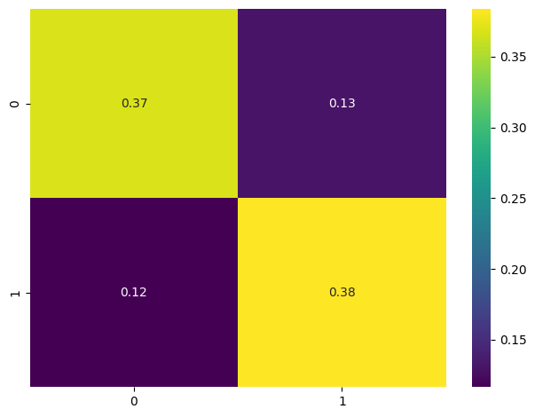

```python
results_dict['SE-ResNet18'] = print_results(model, y_test, y_pred, y_pred_proba)
```